# 2nd Chance Survey | Plastic and Reconstructive Surgery Workforce and Facility Capacity

Sabina Rodriguez

20 November, 2026

# 1 Executive Summary

The 2nd Chance Survey provides a descriptive snapshot of plastic and reconstructive surgery (PRS) practice and facility capacity among **42 eligible respondents** practising in sub-Saharan Africa. The linked facility data identify **52 distinct facility names**. These observations describe the **participating sample**, not national surgeon supply or the regional prevalence of shortages.

The sample was concentrated in Ethiopia (14 respondents, 33.3%) and Rwanda (9, 21.4%). Twenty-five respondents (59.5%) were aged 30–39 and 14 (33.3%) were women. Burns and acute trauma were the most frequently cited top-three workload categories (28 respondents each, 66.7%). Routine wound debridement (97.6%) and split-thickness grafting (95.2%) were common, whereas advanced reconstructive equipment was considerably less accessible. Among respondents, skin substitutes and operating microscopes were reported as unavailable by 66.7% and 57.1%, respectively.

**Priority implications:** strengthen access to specialized equipment and perioperative support; support distributed specialist training and supervision; and validate facility inventories and sampling frames before using these findings for resource allocation or national comparisons. These priorities are **interpretations of descriptive results**, not causal effects established by this survey.

# 2 Introduction and Study Methods

## 2.1 Purpose and scope

This report describes the demographics, training, clinical practice, geographical distribution, staffing estimates, infrastructure, equipment and training activity recorded in the 2nd Chance Survey. It is intended to inform discussion among professional associations, training institutions, funders and health-system stakeholders. The data should not be read as a representative census of surgeons or facilities across sub-Saharan Africa.

## 2.2 Background and objectives

Access to reconstructive surgery is affected by workforce distribution, institutional capacity and the availability of surgical infrastructure. This assessment sought to characterize the participating PRS workforce, its reported workload and the resources available in facilities at which respondents practise.

## 2.3 Design, population and analysis

A cross-sectional, multi-country electronic survey was administered through KoboToolbox. Recruitment used professional membership and institutional networks associated with the College of Surgeons of East, Central and Southern Africa (COSECSA), the West African College of Surgeons (WACS) and 2nd Chance, supplemented by referral and online identification. Survey data were de-identified and analysed descriptively in R. Counts and percentages are given for the relevant set of valid respondent records unless a facility-level denominator is explicitly stated.

**Unit of analysis matters.** Individual surgeons could name multiple practice institutions, and different respondents could describe the same institution. Respondent-level proportions therefore measure *reported access*, not independent facility prevalence. Facility summaries consolidate repeated reports by facility name; modal categorical classifications exclude tied responses, and staffing estimates are shown as median (minimum–maximum) when multiple reports are available. Consequently, the denominator can vary by indicator. Where multiple selections were allowed, percentages may exceed 100% when added together.

The available analytic materials do not establish population-representative sampling weights. Consequently, **surgeon density for the general population is not estimated in this report**, despite its appearance in the original study objective. Population-based inference would require a verified national workforce numerator, denominator and ascertainment strategy.

## 2.4 Ethics and data governance

According to the study documentation, ethics approval was obtained from BASEC and CUREG in Switzerland and the COSECSA Institutional Review Board. Participation was voluntary, consent was collected electronically, no patient-level data were included, and de-identified data were handled by authorized research personnel.

## 2.5 Recruitment, response and data completeness

Recruitment drew on three overlapping contact streams: COSECSA mailing lists, 2nd Chance professional contacts and conference attendance, and contacts identified through online searches and published literature (Figure 1). The COSECSA streams included 129 entries in the Plastic Reconstructive Surgeon Fellow List and 1,665 entries in the Entire Surgeon Membership List, yielding 1,794 combined list entries **before deduplication**. The 2nd Chance Professional Network contributed 57 entries and conference attendance records contributed 40 entries (97 combined). Online sources contributed another 34 entries. The initial aggregate was therefore **1,925 list entries** (1,794 + 97 + 34); after removal of **141 duplicates** (105 COSECSA, 33 2nd Chance and 3 online-source duplicates), **1,784 unique contacts** remained. These are contact-record counts rather than a verified number of eligible, invited surgeons.

A narrower PRS-targeted stream combined the 129 COSECSA PRS fellow entries, 97 2nd Chance entries and 34 online-source entries (**260 entries**). After removing **27 duplicates** (24 from 2nd Chance and 3 from online sources), this stream contained **233 unique PRS-targeted contacts**. This subgroup overlaps with the overall contact pool and **must not be added** to its 1,784 contacts.

Fifty-one individuals accessed the survey. Nine were excluded: one declined informed consent and eight were not currently practising in sub-Saharan Africa. The analytic sample thus comprised **42 eligible participants**, representing **82.4% of survey accesses** (42/51). Using the recorded contact pools as reference denominators, the eligible-participant yield was **2.4% of all unique contacts** (42/1,784) and **18.0% of PRS-targeted contacts** (42/233). These figures are described as *recruitment yields*, **not confirmed invitation response rates**, because the diagram does not establish the numbers of delivered invitations or eligible contacts reached. The COSECSA general membership count is marked as provisional in the source figure and should be confirmed before publication.

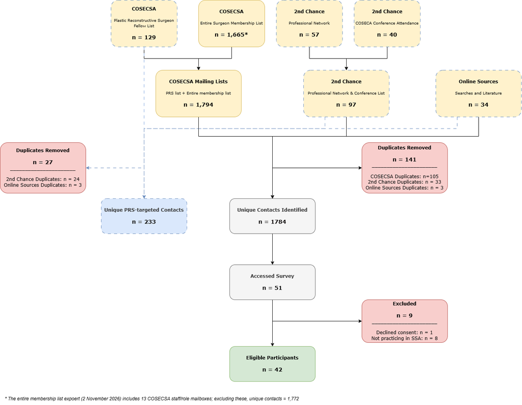

Figure 1. Participant identification and inclusion flowdiagram. Numbers highlighted in red are to be confirmed with COSECSA

One reported specialty accreditation year of 1950 conflicted with the respondent’s age and was treated as missing for accreditation-year analyses. The respondent was retained for all other analyses. Therefore, analyses of accreditation year use **41 valid observations** rather than 42.

# 3 Respondent Characteristics

## 3.1 Age and Gender

Table 1 summarizes respondents’ demographic characteristics and countries of practice. Age, gender, and geographic distributions are reported as frequencies and percentages, with denominators based on available responses for each characteristic.

The participating workforce was predominantly young: the 30–39 age group was the largest, comprising 25 respondents (59.5%), followed by the 40–49 group (n = 6; 14.3%) and the 50–59 group (n = 5; 11.9%). Four respondents (9.5%) were under 30 years of age, and 2 (4.8%) were older than 59.

Participant Characteristics

N = 42 respondents

| Surgeons (age groups), n (%) | N = 42 respondents |
| --- | --- |
| 30-39 | 25 (59.5%) |
| 40-49 | 6 (14.3%) |
| 50-59 | 5 (11.9%) |
| <30 | 4 (9.5%) |
| >59 | 2 (4.8%) |
| Surgeons by gender, n (%) | N = 42 respondents |
| Male | 28 (66.7%) |
| Female | 14 (33.3%) |
| Country of Practice, n (%) | N = 42 respondents |
| Ethiopia | 14 (33.3%) |
| Rwanda | 9 (21.4%) |
| Kenya | 4 (9.5%) |
| Uganda | 4 (9.5%) |
| Democratic Republic of the Congo | 2 (4.8%) |
| Nigeria | 2 (4.8%) |
| Tanzania | 2 (4.8%) |
| Burundi | 1 (2.4%) |
| Côte d'Ivoire | 1 (2.4%) |
| Malawi | 1 (2.4%) |
| Somalia | 1 (2.4%) |
| Togo | 1 (2.4%) |

Male respondents outnumbered female respondents (28 [66.7%] vs 14 [33.3%]). The demographic pyramid in Figure 2 illustrates how this age and gender profile is distributed across the sample; the concentration in the 30–39 group is consistent among both male and female respondents and reinforces the predominantly early-career composition of the surveyed workforce.

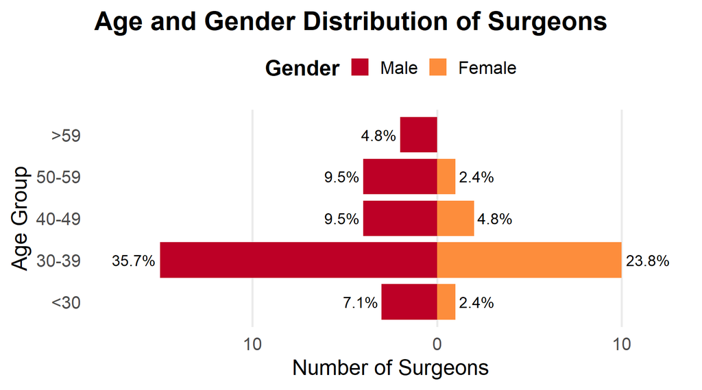

## 3.2 Country of Practice

Respondents reported practising plastic surgery across multiple countries in Sub-Saharan Africa, with Ethiopia accounting for the largest share of reported practice locations (n = 14; 33.3%), followed by Rwanda (n = 9; 21.4%), Kenya (n = 4; 9.5%), Uganda (n = 4; 9.5%), the Democratic Republic of the Congo (n = 2; 4.8%), Nigeria (n = 2; 4.8%), and Tanzania (n = 2; 4.8%). Five additional countries—Burundi, Côte d’Ivoire, Malawi, Somalia and Togo—each contributed one response. These figures are tabulated from the country-of-practice responses. If the source field permits multiple countries per respondent, country counts are mentions and should not be interpreted as independent headcounts. The geographic distribution was strongly concentrated in East Africa, with Ethiopia and Rwanda together accounting for more than half of all country mentions. This concentration likely reflects the geographic reach of the COSECSA recruitment network and should not be interpreted as representative of the overall PRS workforce distribution across SSA. Figure 3 presents the geographic distribution mapped across the continent.

[figure not shown]

# 4 Professional Training

Professional training characteristics were examined to describe the educational qualifications, accreditation pathways, years since specialty accreditation, and current professional positions of participating surgeons.

## 4.1 Years Since Specialty Accreditation

The vast majority of respondents — 30 of the 41 with valid accreditation data (73.2%) — received their specialty accreditation in 2020 or later, confirming the early-career profile of the sample. A further 5 respondents (12.2%) were accredited between 2010 and 2019, and 6 (14.6%) between 2000 and 2009. No respondents reported accreditation before 2000 (the anomalous 1950 value was excluded as described in the data completeness section above). The distribution of years since accreditation is displayed in Figure 4; the red dashed line marks the median, which falls within the first three years post-accreditation, underscoring the junior composition of the workforce.

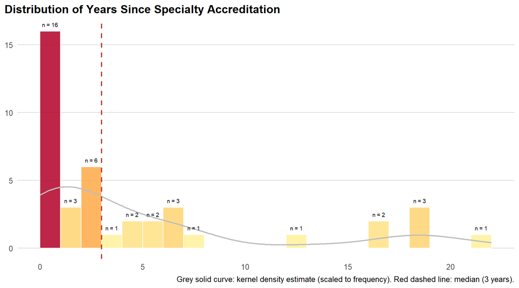

## 4.2 Professional Training Background

Table 2 summarizes respondents’ professional qualifications, primary accreditation bodies, and periods of specialty accreditation. These findings characterize the training backgrounds and accreditation histories represented within the surveyed workforce.

**Professional Training Background**

Total sample: N = 42

| Characteristic | N | % |
| --- | --- | --- |
| Highest Qualification | 42 |  |
| Fellowship | 19 | 45.2 |
| Membership qualification | 12 | 28.6 |
| Master’s degree in Surgery | 7 | 16.7 |
| Doctoral/research degree | 2 | 4.8 |
| Primary medical degree | 2 | 4.8 |
| Primary Accreditation Body | 42 |  |
| COSECSA | 22 | 52.4 |
| National training program | 14 | 33.3 |
| International training program | 3 | 7.1 |
| WACS | 2 | 4.8 |
| Other | 1 | 2.4 |
| Year of Specialty Accreditation | 41 |  |
| 2000-2009 | 6 | 14.6 |
| 2010-2019 | 5 | 12.2 |
| 2020+ | 30 | 73.2 |

## 4.3 Current Professional Position

Consultant/Attending surgeons were the most common professional position, comprising 16 respondents (38.1%). Residents and trainees accounted for 15 respondents (35.7%), making trainees collectively the second largest group. Academic faculty and Fellows each accounted for 4 respondents (9.5% each), and Department heads/chairs for 3 (7.1%). The high proportion of trainees and early-career consultants (73.8% combined) is consistent with the age and accreditation data and indicates that the surveyed workforce is predominantly junior-to-mid-career.

**Current Professional Position**

Total sample: N = 42

| Professional Position | N | % |
| --- | --- | --- |
| Academic faculty | 4 | 9.5 |
| Department head/chair | 3 | 7.1 |
| Consultant/Attending surgeon | 16 | 38.1 |
| Resident/Trainee | 15 | 35.7 |
| Fellow | 4 | 9.5 |

## 4.4 Subspecialty

Respondents could select multiple subspecialties. Reported areas of practice spanned the breadth of plastic and reconstructive surgery, including burn surgery, hand surgery, craniofacial and cleft surgery, microsurgery, aesthetic surgery, and general reconstructive surgery, among others. Because respondents could identify with more than one subspecialty, percentages are not expected to total 100% and are reported by subspecialty in Figure 5. The diversity of subspecialties reported — including both high-volume reconstructive areas such as burns and trauma and lower-volume disciplines such as microsurgery and oncoplastics — reflects the breadth of clinical demands facing the PRS workforce in the region.

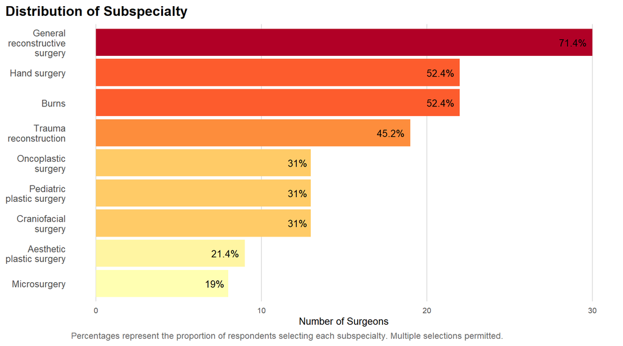

# 5 Practice Settings

Clinical practice settings were examined to characterize the institutions where respondents reported providing surgical services. Because individual surgeons may practise at multiple institutions and multiple respondents may report the same facility, facility-level and respondent-level findings are presented separately throughout this section.

## 5.1 Facilities Reported by Respondents

Respondents collectively identified 52 unique healthcare facilities across 12 countries. The University Teaching Hospital of Kigali (CHUK) was the most frequently cited facility, reported by 8 respondents, followed by ALERT Comprehensive Specialized Hospital in Ethiopia (5 respondents) and Yekatit 12 Hospital Medical College, also in Ethiopia (4 respondents). Rwanda Military Teaching and Referral Hospital was cited by 3 respondents; AIC Kijabe Hospital (Kenya), AaBET Hospital, Felege Hiwot Hospital, and Worabe Comprehensive Specialized Hospital (Ethiopia), and Mulago National Referral Hospital (Uganda) were each cited by 2 respondents. The remaining 43 facilities were each cited by a single respondent. The most frequently named institutions were in Ethiopia and Rwanda; repeated mentions should not be mistaken for additional independent facilities.

## 5.2 Facility Characteristics

Table 5 summarizes the distribution of the 52 unique facilities across geographic setting, facility level, and ownership type. The majority of facilities were located in urban areas (n = 45; 86.5%), with only 7 (13.5%) in rural settings. Facilities were broadly distributed across administrative levels: central, provincial, and university hospitals each accounted for 11 facilities (21.2% each), followed by district hospitals (n = 9; 17.3%) and central university hospitals (n = 7; 13.5%). In terms of ownership, public facilities were the most common (n = 18; 34.6%), followed closely by private facilities (n = 17; 32.7%). Quasi-governmental, NGO, and mission facilities accounted for a further 14 facilities combined. The mix of public, private, and faith-based institutions suggests that PRS services in the region are delivered across a heterogeneous set of institutional environments.

Facility Characteristics

N = 52 facilities

| Urban vs. Rural, n (%) | N = 52 facilities |
| --- | --- |
| urban | 45 (86.5%) |
| rural | 7 (13.5%) |
| Level of Health Facility, n (%) | N = 52 facilities |
| central | 11 (21.2%) |
| provincial | 11 (21.2%) |
| university | 11 (21.2%) |
| district | 9 (17.3%) |
| central university | 7 (13.5%) |
| other | 1 (1.9%) |
| provincial central | 1 (1.9%) |
| provincial university | 1 (1.9%) |
| Facility Ownership Type, n (%) | N = 52 facilities |
| public | 18 (34.6%) |
| private | 17 (32.7%) |
| quasi_gov | 6 (11.5%) |
| ngo | 5 (9.6%) |
| mission | 3 (5.8%) |
| military | 2 (3.8%) |
| other | 1 (1.9%) |

## 5.3 Multiple Facilities

A notable proportion of respondents reported practising at more than one facility. Among the 42 respondents, 19 (45.2%) reported working at a single institution, while 16 (38.1%) reported two facilities, 5 (11.9%) reported three, and 2 (4.8%) reported four. Practice across multiple institutions increases the aggregate service reach of individual surgeons but may also reflect fragmented or cross-subsidised service delivery — a pattern worth exploring in subsequent analyses.

Distribution of Number of Facilities

N = 42 respondents

| Number of Servicing Facilities, n (%) | N = 42 facilities |
| --- | --- |
| 1 | 19 (45.2%) |
| 2 | 16 (38.1%) |
| 3 | 5 (11.9%) |
| 4 | 2 (4.8%) |

# 6 Workforce Profile

Respondents provided staffing estimates — plastic and reconstructive surgeons (PRS), PRS trainees, operating theatre (OT) nurses, and physiotherapists — for each of their reported facilities. Where multiple respondents reported the same facility, values are presented as median (minimum–maximum) to account for variation between individual estimates; single-respondent facilities report the value directly. Staffing counts were not independently verified and represent self-reported estimates.

## 6.1 Staffing Numbers per Facility

Staffing numbers varied substantially across facilities and countries. Table 6 presents facility-level workforce estimates grouped by country. Among listed single-respondent facilities, Saint Paul’s Hospital Millennium Medical College in Ethiopia reported 10 PRS surgeons, 17 trainees, 20 operating theatre nurses and 3 physiotherapists. This is a reported estimate, not a verified staffing census. Kenyatta National Hospital in Kenya reported a notably high trainee-to-surgeon ratio of 5:1 (5 surgeons, 25 trainees, 15 OT nurses, 4 physiotherapists). King Faisal Hospital in Rwanda also reported 25 trainees (alongside 2 PRS surgeons, 10 operating theatre nurses and 2 physiotherapists), **tied** with Kenyatta National Hospital for the largest single facility trainee estimate in the displayed table. Facilities with multiple respondents showed broad within-facility variation in staffing estimates: at ALERT Comprehensive Specialized Hospital in Ethiopia, the median number of reported PRS surgeons was 8 (range 7–9), with 13 trainees (10–26), 24 OT nurses (16–30), and 6 physiotherapists (5–10). The University Teaching Hospital of Kigali (CHUK), the most frequently cited facility with 8 reporting respondents, had a notably low median PRS surgeon count of 1 (range 1–4) alongside a median of 12.5 trainees (range 5–25), suggesting that training activity may outpace the available specialist workforce at this institution.

Nkinga Referral Hospital (Tanzania), Kalembelembe Pediatric Hospital (DR Congo) and CHR Notsé (Togo) each had a reported estimate of zero PRS surgeons. **Kalkaal Hospital (Somalia) reported one PRS surgeon** and is not included in the zero-surgeon group. These estimates may reflect local reporting or service arrangements and need facility verification. These findings highlight substantial heterogeneity in PRS workforce depth across the region, even within countries with a relatively larger respondent presence.

Reported Surgical Workforce by Facility and Country

Facility-level workforce estimates

| Facility | Respondents (n) | PRS surgeons | PRS trainees | OT nurses | Physiotherapists |
| --- | --- | --- | --- | --- | --- |
| Burundi |  |  |  |  |  |
| Matana Referral Hospital | 1 | 1 | 0 | 1 | 1 |
| Tanganyika Hospital | 1 | 2 | 1 | 2 | 0 |
| Côte d’Ivoire |  |  |  |  |  |
| Hôpital Jean Baptiste Vatelot | 1 | 3 | 4 | 19 | 2 |
| Hôpital des Carmélites de Sakassou | 1 | 3 | 2 | 8 | 1 |
| Institut Raoul Follereau de Côte d'Ivoire | 1 | 2 | 5 | 2 | 7 |
| DR Congo |  |  |  |  |  |
| Kalembelembe Pediatric Hospital | 1 | 0 | 1 | 8 | 0 |
| Ethiopia |  |  |  |  |  |
| ALERT Comprehensive Specialized Hospital | 5 | 8 (7–9) | 13 (10–26) | 24 (16–30) | 6 (5–10) |
| AaBET Hospital | 2 | 7 (4–10) | 11.5 (10–13) | 15 | 4.5 (2–7) |
| Adama Hospital Medical College | 1 | 2 | 0 | 7 | 3 |
| Addis Hiwot Hospital | 1 | 2 | 0 | 12 | 2 |
| Black Lion Hospital | 1 | 5 | 15 | 4 | 15 |
| Careland | 1 | 1 | 0 | 2 | 2 |
| Dessie Hospital | 1 | 2 | 0 | 6 | 1 |
| Ethio Tebib Hospital | 1 | 1 | 0 | 5 | 4 |
| Felege Hiwot Hospital | 2 | 2 | 0 | 8 | 4 |
| Heal Venture | 1 | 1 | 0 | 4 | 0 |
| Jimma University Medical Center | 1 | 3 | 0 | 9 | 2 |
| Meqrez Hospital | 1 | 3 | 0 | 8 | 5 |
| Saint Paul's Hospital Millennium Medical College | 1 | 10 | 17 | 20 | 3 |
| Worabe Comprehensive Specialized Hospital | 2 | 2.5 (2–3) | 0.5 (0–1) | 7.5 (5–10) | 1.5 (1–2) |
| Yekatit 12 Hospital Medical College | 4 | 5 (5–7) | 23 (13–30) | 12.5 (10–15) | 4.5 (3–6) |
| Yordanos Hospital | 1 | 2 | 0 | 10 | 3 |
| Yoya General Hospital | 1 | 2 | 0 | 9 | 2 |
| Kenya |  |  |  |  |  |
| AIC CURE International Hospital | 1 | 2 | 0 | 6 | 10 |
| AIC Kijabe Hospital | 2 | 3 | 5 | 4 | 7.5 (5–10) |
| Avenue Hospital | 1 | 4 | 0 | 4 | 2 |
| Defence Forces Memorial Hospital | 1 | 1 | 0 | 0 | 1 |
| Gertrude's Children's Hospital | 1 | 3 | 0 | 10 | 10 |
| Kenyatta National Hospital | 1 | 5 | 25 | 15 | 4 |
| Malawi |  |  |  |  |  |
| Kamuzu Central Hospital | 1 | 2 | 0 | 8 | 2 |
| Queen Elizabeth Central Hospital | 1 | 3 | 3 | 30 | 4 |
| Nigeria |  |  |  |  |  |
| Grandville Medical and Laser Abuja | 1 | 2 | 1 | 6 | 1 |
| Grandville Medical and Laser Lekki | 1 | 1 | 0 | 6 | 2 |
| Grandville Medical and Laser Surulere | 1 | 3 | 0 | 8 | 1 |
| Grandville Trauma Center Lekki | 1 | 3 | 0 | 10 | 2 |
| University College Hospital, Ibadan | 1 | 4 | 4 | 3 | 3 |
| WoundSolutions Clinic | 1 | 1 | 0 | 1 | 0 |
| Rwanda |  |  |  |  |  |
| King Faisal Hospital | 1 | 2 | 25 | 10 | 2 |
| Rwanda Military Teaching and Referral Hospital | 3 | 2 (2–3) | 5 (4–25) | 10 (2–12) | 2 (1–5) |
| University Teaching Hospital of Kigali (CHUK) | 8 | 1 (1–4) | 12.5 (5–25) | 3 (2–10) | 1 (0–2) |
| Somalia |  |  |  |  |  |
| Kalkaal Hospital | 1 | 1 | 0 | 0 | 1 |
| Tanzania |  |  |  |  |  |
| Muhimbili National Hospital | 1 | 7 | 6 | 2 | 2 |
| Nkinga Referral Hospital | 1 | 0 | 0 | 3 | 1 |
| Togo |  |  |  |  |  |
| CHR Notse | 1 | 0 | 0 | 0 | 1 |
| Centre Hospitalier Universitaire Sylvanus Olympio (CHUSO) | 1 | 1 | 1 | 3 | 3 |
| Polyclinelle | 1 | 1 | 1 | 3 | 0 |
| Uganda |  |  |  |  |  |
| Children's Surgical Hospital | 1 | 1 | 0 | 3 | 2 |
| Comprehensive Rehabilitation Services in Uganda (CORSU) | 1 | 4 | 4 | 3 | 4 |
| Kayunga Regional Referral Hospital | 1 | 1 | 3 | 3 | 2 |
| Kiruddu National and Referral Hospital | 1 | 5 | 17 | 10 | 2 |
| Mulago National Referral Hospital | 2 | 2 (1–3) | 5.5 (2–9) | 3 (1–5) | 3 (1–5) |
| Nakasero Hospital Limited | 1 | 4 | 0 | 2 | 2 |

For facilities with multiple valid reports, values represent median (minimum–maximum). For facilities with one valid report, the reported count is shown directly. Staffing counts were not independently verified.

# 7 Service Delivery

## 7.1 Scope of Procedures Performed

Figure 6 displays the distribution of surgeon-reported procedural frequency across 18 PRS procedures, ordered from most to least routinely performed. Wound debridement was the most universally performed procedure, reported as routinely performed by 97.6% of respondents. Split-thickness skin grafting (95.2%), full-thickness skin grafting (90.5%), burn reconstruction (88.1%), and local/pedicled flaps (76.2%) were also routinely performed by large majorities, confirming that wound management and burn care procedures form the core of clinical activity across the surveyed workforce. Burn excision (73.8%), contracture release (71.4%), and tendon repair (71.4%) were likewise routinely performed by a majority of respondents.

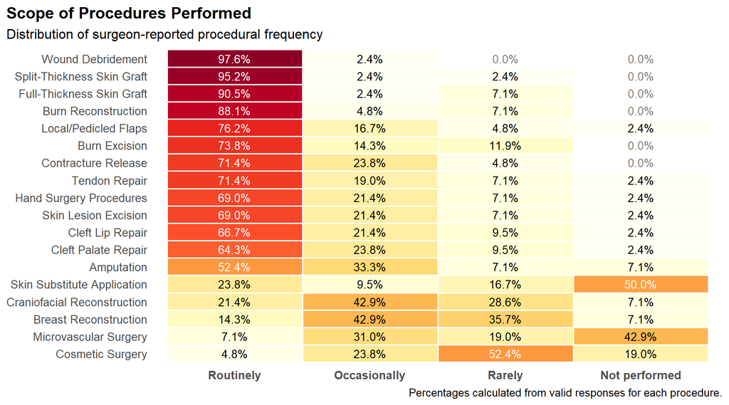

## 7.2 Workload

Figure 7 presents the most commonly selected top-three reconstructive workload categories reported by surgeons (N = 42). Burns and acute trauma were the leading workload categories, each selected by 66.7% of respondents (n = 28). Hand surgery ranked third, cited by 50.0% (n = 21), followed by scar revision (35.7%; n = 15) and cleft conditions (26.2%; n = 11). Cancer-related reconstruction was selected by 11.9% of respondents (n = 5). Breast reconstruction, aesthetic surgery, and other categories each accounted for fewer than 3% of selections. The dominance of burns, trauma, and hand surgery aligns closely with the high procedural frequency of wound debridement, skin grafting, and tendon repair observed in the procedures data, and is consistent with the broader epidemiological burden of acute acquired conditions documented across SSA.

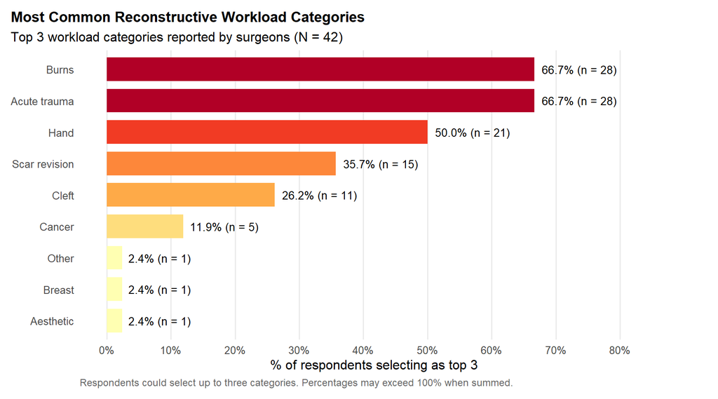

# 8 Infrastructure

## 8.1 Availability: Surgeon-reported Heatmap

Figure 8 presents the surgeon-reported availability of 14 infrastructure items across the 42 respondents, categorized as consistently available, intermittently available, or not available. X-ray was the most consistently available item (97.6%), followed by oxygen supply and ultrasound (both 90.5%), electricity (85.7%), and dedicated operating room time for PRS and running water (both 83.3%). Blood bank and physiotherapy services were consistently available to 81.0% of respondents, and CT scanner to 76.2%. Histopathology services were consistently available to 66.7% of respondents, though intermittently available to a further 21.4%. Intensive care unit access showed more variability, with 52.4% reporting consistent availability and 40.5% intermittent availability. Occupational therapy services, temperature-controlled operating rooms, and patient warming devices were the least consistently available items, with consistent availability reported by only 45.2%, 45.2%, and 40.5% of respondents respectively.

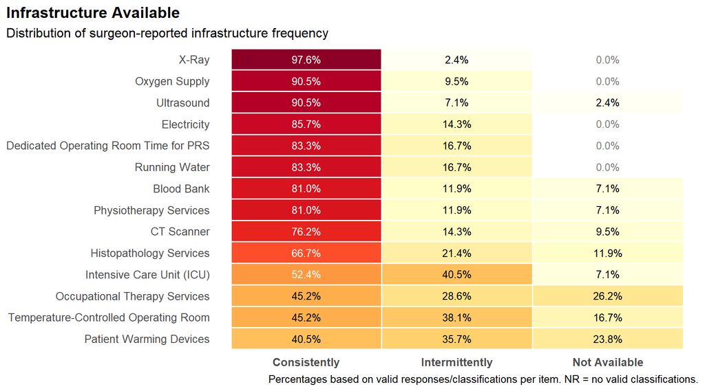

## 8.2 Consistently Available Infrastructure

Figure 9 presents the mean percentage of assessed infrastructure items consistently available at complete facilities, disaggregated by country. Rwanda reported the highest mean consistent availability across assessed items (96.4%), followed by Kenya and Togo (both 85.7%) and Uganda (78.6%). Nigeria (75.0%), Tanzania (71.4%), and Somalia (71.4%) fell in the mid-range. Ethiopia had a mean consistent availability of 64.3% among facilities included in that infrastructure-country analysis; this subset is distinct from the eight Ethiopian facilities in the training summary. The lowest values were observed in Côte d’Ivoire (57.1%), Malawi (53.6%), DR Congo (35.7%), and Burundi (21.4%), though these figures should be interpreted with caution given the small number of facilities assessed in each country.

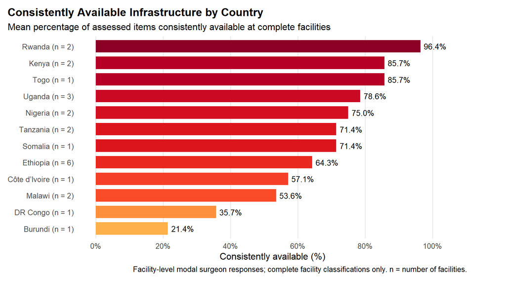

## 8.3 Heatmap by Country and Infrastructure

The country-by-infrastructure heatmap in Figure 10 provides additional granularity on item-level availability across the 12 countries represented.

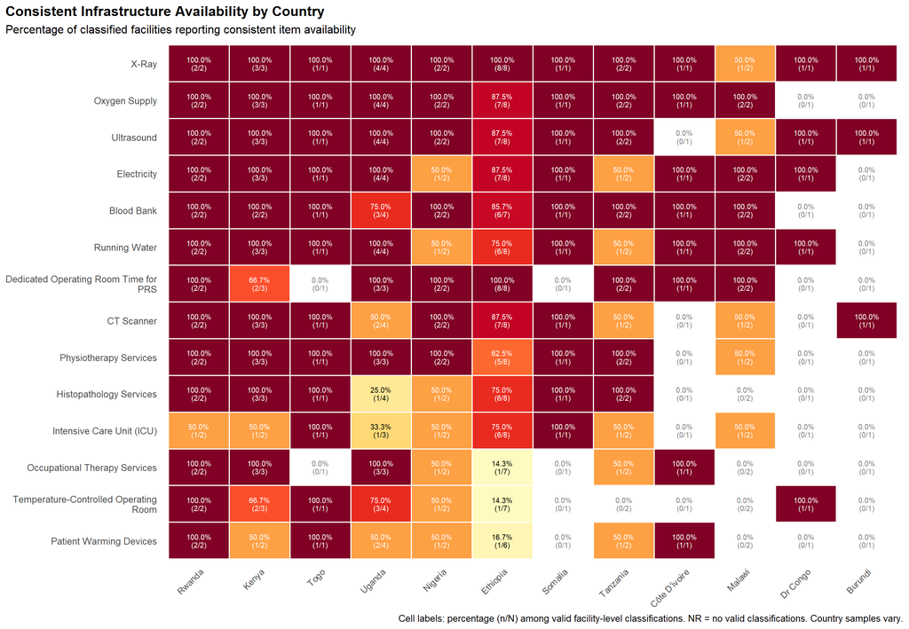

## 8.4 Critical Infrastructure Gaps

Figure 11 compares consistently available with unavailable infrastructure among the facility classifications available for each item. The underlying facility pool includes up to 28 facilities, but **item-specific valid denominators vary**. Among the 14 assessed items, X-ray had no reported unavailability (0%) and was consistently available in 96.4% of facilities. Items with zero reported unavailability and high consistent availability included running water (consistently available 82.1%), electricity (85.7%), oxygen supply (89.3%), and dedicated OR time for PRS (81.5%). By contrast, the items with the highest rates of unavailability were patient warming devices (unavailable at 32.0% of facilities, consistently available at only 40.0%), occupational therapy services (unavailable at 30.8%, consistently available at 46.2%), histopathology services (unavailable at 17.9%), and temperature-controlled operating rooms (unavailable at 14.8%). ICU access was absent in 11.5% of facilities. These gaps are particularly consequential for the management of critically ill burn and trauma patients, for whom ICU access, temperature control, and histopathology are integral to safe perioperative care.

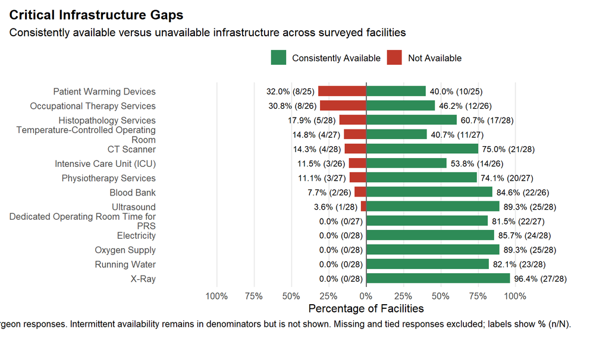

# 9 Equipment

## 9.1 Availability: Surgeon-reported Heatmap

Figure 12 presents the surgeon-reported consistent availability of 18 equipment items across the 42 respondents. Urinary catheters and pulse oximeters were consistently available to all respondents (100.0%), followed by IV fluids (97.6%), functional anesthesia machines and sterilization equipment (both 95.2%), and mechanical ventilators (83.3%). Fine monofilament sutures were consistently available to 81.0% of respondents, and dermatome/Humby knives to 78.6%. Tourniquets and electrosurgical units were consistently available to approximately 71% of respondents, while burn dressings and skin meshers were consistently available to 69.0% and 66.7% respectively.

In contrast, the most consistently unavailable items were skin substitutes (not available to 66.7%), operating microscopes (not available to 57.1%), and negative pressure wound therapy/VAC devices (not available to 40.5%). Microsurgical instruments were unavailable to 40.5% of respondents, and surgical loupes to 16.7%. These findings indicate a clear gap between essential anaesthetic and perioperative supplies — which are broadly available — and advanced or PRS-specific equipment required for complex reconstructive procedures.

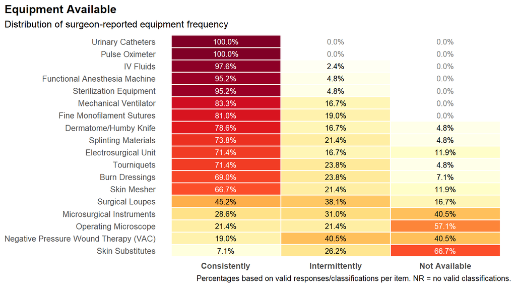

## 9.2 Facility-level Equipment: Essential vs. Specialized

Figure 13 presents equipment availability from the facility-level dataset (up to 28 classified facilities), grouped into essential, PRS-specific and advanced items. Percentages use item-specific valid facility classifications. Essential items showed the highest levels of consistent availability: pulse oximeters and urinary catheters were available at 100% of facilities, IV fluids and functional anesthesia machines at 96.4%, and sterilization equipment at 92.9%. Fine monofilament sutures were consistently available at 81.5% of facilities.

Among PRS-specific items, the dermatome/Humby knife — a core tool for split-thickness skin grafting — was consistently available at 84.6% of facilities. Skin meshers and surgical loupes showed lower availability at 63.0% and 44.0% of facilities respectively. Microsurgical instruments, essential for free-flap and replantation procedures, were consistently available at only 22.2% of facilities.

Advanced items showed the greatest gaps: the mechanical ventilator, while classified as advanced in this framework, was available at 82.1% of facilities, likely reflecting its role in routine anaesthesia care. Negative pressure wound therapy (VAC) was consistently available at only 22.2% of facilities, the operating microscope at 14.3%, and skin substitutes at just 3.7%. Taken together, these findings indicate that while essential perioperative equipment is reasonably well distributed, specialized reconstructive and advanced surgical equipment remains critically scarce across the surveyed facilities.

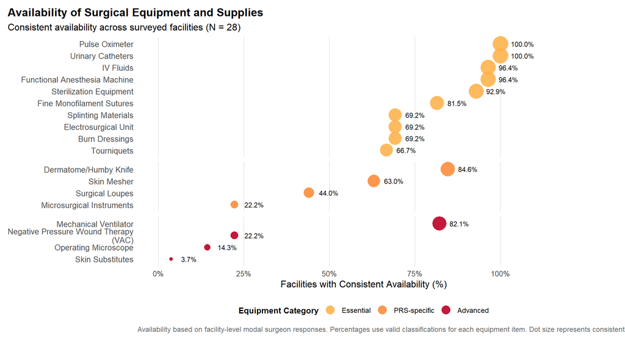

# 10 Training

## 10.1 Training Capacity at Facilities

The training table describes 28 unique facilities for which one or more training indicators could be classified; valid denominators differ by indicator and country. Of 28 facilities represented in the training table, 17 of 27 with classifiable CPD responses (63.0%) reported opportunities, 17 of 28 (60.7%) reported resident/fellow training, and 15 of 26 (57.7%) reported hosting visiting outreach teams. Each activity was reported by more than half of the facilities with valid classifications; these are **separate indicators**, so the results do not establish the proportion of facilities offering at least one activity.

Country-level variation in training capacity was considerable. All three assessed Kenyan facilities (100.0%) offered CPD opportunities and trained PRS residents or fellows. Both Nigerian and Rwandan facilities with complete data similarly reported 100% CPD availability and resident training. In Burundi and DR Congo (one classified facility each), no CPD opportunities, visiting outreach teams or resident/fellow training were reported. The Somalia facility reported **visiting outreach teams (1/1)** but no CPD opportunities or resident/fellow training. Ethiopia contributed eight facilities to the training summary, although only seven had valid, unambiguous responses for CPD and outreach (CPD 4/7, 57.1%; outreach 5/7, 71.4%); resident/fellow training was reported by 4/8 (50.0%). In Malawi, neither of two facilities reported CPD opportunities (0/2), while one reported hosting outreach teams and one reported training residents/fellows (1/2, 50.0% each).

The concentration of training activity in a small number of well-resourced facilities — particularly teaching hospitals in Ethiopia, Kenya, and Rwanda — underscores both the importance of these institutions as regional training hubs and the uneven distribution of capacity-building infrastructure across the broader SSA context. Strengthening training capacity at district and provincial facilities, particularly in countries with minimal current activity, will be essential to expanding the PRS workforce pipeline across the region.

**Training Capacity at Facilities**

Overall and by country

|  | Yes N (%) | No N (%) |
| --- | --- | --- |
| Overall (N = 28 facilities) |  |  |
| Continuing Professional Development Opportunities Available | 17 (63.0%) | 10 (37.0%) |
| Hosts Visiting Outreach Teams | 15 (57.7%) | 11 (42.3%) |
| Trains PRS Residents/Fellows | 17 (60.7%) | 11 (39.3%) |
| Country: Burundi (N = 1 facilities) |  |  |
| Continuing Professional Development Opportunities Available | 0 (0.0%) | 1 (100.0%) |
| Hosts Visiting Outreach Teams | 0 (0.0%) | 1 (100.0%) |
| Trains PRS Residents/Fellows | 0 (0.0%) | 1 (100.0%) |
| Country: Cote d'Ivoire (N = 1 facilities) |  |  |
| Continuing Professional Development Opportunities Available | 1 (100.0%) | 0 (0.0%) |
| Hosts Visiting Outreach Teams | 0 (0.0%) | 1 (100.0%) |
| Trains PRS Residents/Fellows | 1 (100.0%) | 0 (0.0%) |
| Country: DR Congo (N = 1 facilities) |  |  |
| Continuing Professional Development Opportunities Available | 0 (0.0%) | 1 (100.0%) |
| Hosts Visiting Outreach Teams | 0 (0.0%) | 1 (100.0%) |
| Trains PRS Residents/Fellows | 0 (0.0%) | 1 (100.0%) |
| Country: Ethiopia (N = 8 facilities) |  |  |
| Continuing Professional Development Opportunities Available | 4 (57.1%) | 3 (42.9%) |
| Hosts Visiting Outreach Teams | 5 (71.4%) | 2 (28.6%) |
| Trains PRS Residents/Fellows | 4 (50.0%) | 4 (50.0%) |
| Country: Kenya (N = 3 facilities) |  |  |
| Continuing Professional Development Opportunities Available | 3 (100.0%) | 0 (0.0%) |
| Hosts Visiting Outreach Teams | 2 (66.7%) | 1 (33.3%) |
| Trains PRS Residents/Fellows | 3 (100.0%) | 0 (0.0%) |
| Country: Malawi (N = 2 facilities) |  |  |
| Continuing Professional Development Opportunities Available | 0 (0.0%) | 2 (100.0%) |
| Hosts Visiting Outreach Teams | 1 (50.0%) | 1 (50.0%) |
| Trains PRS Residents/Fellows | 1 (50.0%) | 1 (50.0%) |
| Country: Nigeria (N = 2 facilities) |  |  |
| Continuing Professional Development Opportunities Available | 2 (100.0%) | 0 (0.0%) |
| Hosts Visiting Outreach Teams | 0 (0.0%) | 2 (100.0%) |
| Trains PRS Residents/Fellows | 2 (100.0%) | 0 (0.0%) |
| Country: Rwanda (N = 2 facilities) |  |  |
| Continuing Professional Development Opportunities Available | 2 (100.0%) | 0 (0.0%) |
| Hosts Visiting Outreach Teams | 1 (50.0%) | 1 (50.0%) |
| Trains PRS Residents/Fellows | 2 (100.0%) | 0 (0.0%) |
| Country: Somalia (N = 1 facilities) |  |  |
| Continuing Professional Development Opportunities Available | 0 (0.0%) | 1 (100.0%) |
| Hosts Visiting Outreach Teams | 1 (100.0%) | 0 (0.0%) |
| Trains PRS Residents/Fellows | 0 (0.0%) | 1 (100.0%) |
| Country: Tanzania (N = 2 facilities) |  |  |
| Continuing Professional Development Opportunities Available | 1 (50.0%) | 1 (50.0%) |
| Hosts Visiting Outreach Teams | 2 (100.0%) | 0 (0.0%) |
| Trains PRS Residents/Fellows | 1 (50.0%) | 1 (50.0%) |
| Country: Togo (N = 1 facilities) |  |  |
| Continuing Professional Development Opportunities Available | 0 (0.0%) | 1 (100.0%) |
| Hosts Visiting Outreach Teams | 1 (100.0%) | 0 (0.0%) |
| Trains PRS Residents/Fellows | 0 (0.0%) | 1 (100.0%) |
| Country: Uganda (N = 4 facilities) |  |  |
| Continuing Professional Development Opportunities Available | 4 (100.0%) | 0 (0.0%) |
| Hosts Visiting Outreach Teams | 2 (66.7%) | 1 (33.3%) |
| Trains PRS Residents/Fellows | 3 (75.0%) | 1 (25.0%) |

N represents the number of unique facilities in each section. Percentages are calculated separately for each training indicator using valid, unambiguous facility classifications. Tied and missing responses are excluded from indicator-specific denominators. NR = no valid classified facilities.

## 10.2 Training Needs

Training needs were assessed as a separate surgeon-level item. The visual below summarizes coded themes from free-text answers; participants could contribute more than one theme. Interpret the themes as priorities voiced by respondents, not as a population prevalence estimate.

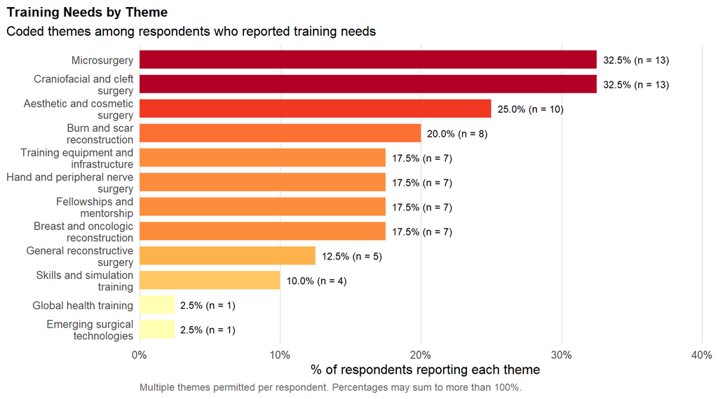

# 11 Interpretation, Priorities and Limitations

## 11.1 Priorities for discussion

**Target equipment gaps:** Examine mechanisms for sharing or procuring microsurgical instruments, operating microscopes, negative-pressure wound therapy equipment and skin substitutes. These recommendations respond to low reported availability and should be reconciled with facility inventories, case mix and maintenance capacity before procurement.

**Strengthen supportive infrastructure:** Assess access to intensive care, warming equipment, occupational therapy and histopathology, particularly where complex burn and reconstructive surgery is performed.

**Invest in clinical training networks:** Use higher-capacity teaching facilities to support supervised rotations, continuing professional development and outreach partnerships; measure training outputs rather than assuming the presence of a training indicator is sufficient.

**Improve workforce intelligence:** Verify unique facility IDs, reconcile contradictory repeated reports and complete a defined recruitment denominator before making country-level policy comparisons or workforce-density statements.

## 11.2 Limitations

The survey relied on purposive and network recruitment and includes a small, unevenly distributed sample; country comparisons are descriptive rather than representative. Respondent access, facility availability and independent institutional capacity are different constructs. Counts provided by multiple respondents at the same facility were not independently validated. Some facility classifications were missing or tied, resulting in item-specific denominators. Training theme coding is based on free text and can include multiple themes per person. Cross-sectional observations cannot establish trends or causality.

## 11.3 Data provenance and reproducibility

The figures and tables in this report are generated by the embedded R code using `clean_data_20261112.rds`, `clean_merged_20261112.rds` and `training_theme_count.rds`. Source dataset versions correspond to the November 12, 2026 cleaned files supplied for this report. The narrative statistics were reconciled against the November 19, 2026 draft PDF; any subsequently modified dataset will require narrative re-review. Recruitment list totals were reconciled to the newly supplied participant flow diagram. The general COSECSA membership count remains provisional, and invitation delivery and eligibility have not been independently verified; contact-based yields should therefore not be interpreted as confirmed response rates.

**Data integrity snapshot:** 42 respondent records; 52 distinct named facilities; 73 facility-response rows.